# Continuous EGPD Models for Temperature Extremes

This vignette demonstrates fitting continuous Extended Generalized Pareto Distribution (EGPD) models to temperature threshold exceedances using the `egpd` package. The data come from the `FCtmax` dataset in the `evgam` package, which records daily maximum temperatures at Fort Collins, Colorado, US from 1970 to 2019.

## Data

The EGPD generalises the classical Generalized Pareto Distribution (GPD) by prepending a transformation G to the uniform component of the GPD. This gives extra flexibility in the body of the distribution while retaining the same Pareto tail behaviour. It is well-suited for modelling threshold exceedances where the standard GPD may be too rigid for the bulk of the data.

We extract summer (June–August) daily maximum temperatures and define exceedances above the 90th percentile.

```r
library(egpd)
library(evgam)
data(FCtmax)

FCtmax$month <- as.integer(format(FCtmax$date, "%m"))
FCtmax$year  <- as.integer(format(FCtmax$date, "%Y"))

summer <- FCtmax[FCtmax$month %in% 6:8, ]
thresh <- quantile(summer$tmax, 0.9)
cat("90th percentile threshold:", thresh, "°C\n")
```

```
#> 90th percentile threshold: 33.9 °C
```

```r
exc_idx <- summer$tmax > thresh
df <- data.frame(
  y    = summer$tmax[exc_idx] - thresh,
  year = summer$year[exc_idx]
)
cat("Number of exceedances:", nrow(df), "out of", nrow(summer), "summer days\n")
```

```
#> Number of exceedances: 395 out of 4593 summer days
```

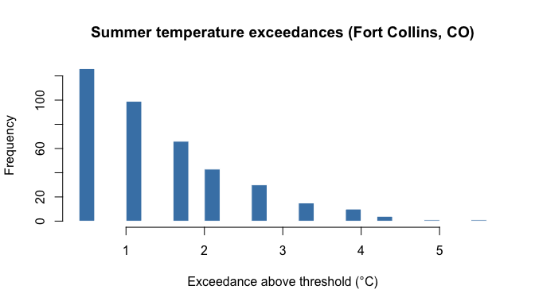

```r
hist(df$y, breaks = 30, col = "steelblue", border = "white",
     main = "Summer temperature exceedances (Fort Collins, CO)",
     xlab = "Exceedance above threshold (°C)", ylab = "Frequency")
```

## Fitting EGPD models

The continuous EGPD family in `egpd()` uses three formula components for models 1, 3, 5, and 6:

- `lpsi`: log-scale parameter (sigma)
- `xi`: shape parameter (xi)
- `lkappa` or `ldelta`: log-G-transformation parameter

Model 4 has a fourth component (`lkappa`) in addition to `ldelta`.

### EGPD Model 1: Power transformation

Model 1 uses G(u) = u^kappa. When kappa = 1, this reduces to the standard GPD.

```r
fit1 <- egpd(list(lpsi = y ~ 1, xi = ~ 1, lkappa = ~ 1),
             data = df, family = "egpd", egpd.args = list(m = 1))
summary(fit1)
```

```
#>
#> ** Parametric terms **
#>
#> logscale
#>             Estimate Std. Error t value Pr(>|t|)
#> (Intercept)    -0.56       0.31   -1.81   0.0351
#>
#> shape
#>             Estimate Std. Error t value Pr(>|t|)
#> (Intercept)     0.16       0.11     1.4   0.0806
#>
#> logkappa
#>             Estimate Std. Error t value Pr(>|t|)
#> (Intercept)     1.35        0.3    4.46 4.08e-06
#>
#> ** Smooth terms **
```

```r
pars1 <- predict(fit1, type = "response")[1, ]
cat("sigma =", round(pars1$scale, 3),
    " xi =", round(pars1$shape, 3),
    " kappa =", round(pars1$kappa, 3), "\n")
```

```
#> sigma = 0.569  xi = 0.158  kappa = 3.855
```

The estimated kappa is well above 1, indicating that the standard GPD (kappa = 1) would underfit the body of the distribution.

### EGPD Model 3: Incomplete beta transformation

Model 3 uses an incomplete beta G-transformation with parameter delta.

```r
fit3 <- egpd(list(lpsi = y ~ 1, xi = ~ 1, ldelta = ~ 1),
             data = df, family = "egpd", egpd.args = list(m = 3))
summary(fit3)
```

```
#>
#> ** Parametric terms **
#>
#> logscale
#>             Estimate Std. Error t value Pr(>|t|)
#> (Intercept)     0.29       0.15    1.89   0.0294
#>
#> shape
#>             Estimate Std. Error t value Pr(>|t|)
#> (Intercept)    -0.17       0.07   -2.47  0.00682
#>
#> logdelta
#>             Estimate Std. Error t value Pr(>|t|)
#> (Intercept)      0.8       0.56    1.43   0.0767
#>
#> ** Smooth terms **
```

### EGPD Model 4: Power-beta transformation

Model 4 combines both transformations with parameters delta and kappa.

```r
fit4 <- egpd(list(lpsi = y ~ 1, xi = ~ 1, ldelta = ~ 1, lkappa = ~ 1),
             data = df, family = "egpd", egpd.args = list(m = 4))
summary(fit4)
```

```
#>
#> ** Parametric terms **
#>
#> logscale
#>             Estimate Std. Error t value Pr(>|t|)
#> (Intercept)    -0.17       0.21   -0.81    0.209
#>
#> shape
#>             Estimate Std. Error t value Pr(>|t|)
#> (Intercept)     0.02       0.09    0.21    0.418
#>
#> logdelta
#>             Estimate Std. Error t value Pr(>|t|)
#> (Intercept)     1.75       0.33    5.26 7.35e-08
#>
#> logkappa
#>             Estimate Std. Error t value Pr(>|t|)
#> (Intercept)     1.44       0.21    6.88    3e-12
#>
#> ** Smooth terms **
```

### EGPD Model 5: Truncated normal transformation

Model 5 uses a truncated normal G-transformation with parameter kappa.

```r
fit5 <- egpd(list(lpsi = y ~ 1, xi = ~ 1, lkappa = ~ 1),
             data = df, family = "egpd", egpd.args = list(m = 5))
summary(fit5)
```

```
#>
#> ** Parametric terms **
#>
#> logscale
#>             Estimate Std. Error t value Pr(>|t|)
#> (Intercept)    -0.95       0.39   -2.47  0.00669
#>
#> shape
#>             Estimate Std. Error t value Pr(>|t|)
#> (Intercept)     0.36       0.14    2.66  0.00393
#>
#> logkappa
#>             Estimate Std. Error t value Pr(>|t|)
#> (Intercept)     3.13       0.57    5.45 2.49e-08
#>
#> ** Smooth terms **
```

### EGPD Model 6: Truncated beta transformation

Model 6 uses a truncated beta G-transformation with parameter kappa.

```r
fit6 <- egpd(list(lpsi = y ~ 1, xi = ~ 1, lkappa = ~ 1),
             data = df, family = "egpd", egpd.args = list(m = 6))
summary(fit6)
```

```
#>
#> ** Parametric terms **
#>
#> logscale
#>             Estimate Std. Error t value Pr(>|t|)
#> (Intercept)    -0.33        0.2   -1.63   0.0516
#>
#> shape
#>             Estimate Std. Error t value Pr(>|t|)
#> (Intercept)     0.12        0.1    1.19    0.117
#>
#> logkappa
#>             Estimate Std. Error t value Pr(>|t|)
#> (Intercept)     1.66       0.27    6.15  3.8e-10
#>
#> ** Smooth terms **
```

### Model comparison

```r
aic_table <- data.frame(
  Model  = c("EGPD-1", "EGPD-3", "EGPD-4", "EGPD-5", "EGPD-6"),
  npar   = c(3, 3, 4, 3, 3),
  logLik = round(c(logLik(fit1), logLik(fit3), logLik(fit4),
                   logLik(fit5), logLik(fit6)), 2),
  AIC    = round(c(AIC(fit1), AIC(fit3), AIC(fit4),
                   AIC(fit5), AIC(fit6)), 2)
)
aic_table
```

```
#>    Model npar  logLik    AIC
#> 1 EGPD-1    3 -478.58 963.16
#> 2 EGPD-3    3 -483.65 973.29
#> 3 EGPD-4    4 -475.05 958.09
#> 4 EGPD-5    3 -482.75 971.51
#> 5 EGPD-6    3 -477.95 961.91
```

## Goodness of fit

We assess model fit using Q–Q plots of randomised quantile residuals. If the model is correct, the residuals should follow a standard normal distribution.

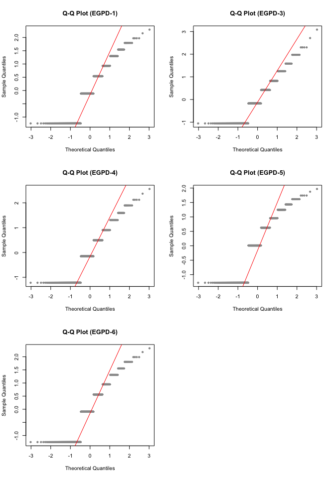

```r
set.seed(1)
par(mfrow = c(3, 2))

r1 <- rqresid(fit1)
qqnorm(r1, main = "Q-Q Plot (EGPD-1)", pch = 20, col = "grey60")
qqline(r1, col = "red")

r3 <- rqresid(fit3)
qqnorm(r3, main = "Q-Q Plot (EGPD-3)", pch = 20, col = "grey60")
qqline(r3, col = "red")

r4 <- rqresid(fit4)
qqnorm(r4, main = "Q-Q Plot (EGPD-4)", pch = 20, col = "grey60")
qqline(r4, col = "red")

r5 <- rqresid(fit5)
qqnorm(r5, main = "Q-Q Plot (EGPD-5)", pch = 20, col = "grey60")
qqline(r5, col = "red")

r6 <- rqresid(fit6)
qqnorm(r6, main = "Q-Q Plot (EGPD-6)", pch = 20, col = "grey60")
qqline(r6, col = "red")

par(mfrow = c(1, 1))
```

We can also compare the fitted survivor function with the empirical one.

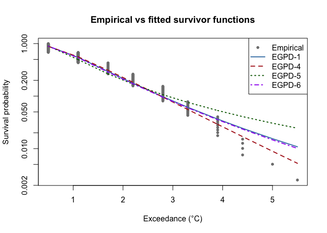

```r
y_sorted <- sort(df$y)
n <- length(y_sorted)
emp_surv <- 1 - (1:n) / (n + 1)

p1 <- predict(fit1, type = "response")[1, ]
surv1 <- 1 - pegpd(y_sorted, sigma = p1$scale, xi = p1$shape,
                    kappa = p1$kappa, type = 1)

p4 <- predict(fit4, type = "response")[1, ]
surv4 <- 1 - pegpd(y_sorted, sigma = p4$scale, xi = p4$shape,
                    delta = p4$delta, kappa = p4$kappa, type = 5)

plot(y_sorted, emp_surv, log = "y", pch = 20, col = "grey50",
     xlab = "Exceedance (°C)", ylab = "Survival probability",
     main = "Empirical vs fitted survivor functions")
lines(y_sorted, surv1, col = "steelblue", lwd = 2)
lines(y_sorted, surv4, col = "firebrick", lwd = 2, lty = 2)
p5 <- predict(fit5, type = "response")[1, ]
surv5 <- 1 - pegpd(y_sorted, sigma = p5$scale, xi = p5$shape,
                    kappa = p5$kappa, type = 2)

p6 <- predict(fit6, type = "response")[1, ]
surv6 <- 1 - pegpd(y_sorted, sigma = p6$scale, xi = p6$shape,
                    kappa = p6$kappa, type = 3)

lines(y_sorted, surv5, col = "darkgreen", lwd = 2, lty = 3)
lines(y_sorted, surv6, col = "purple", lwd = 2, lty = 4)
legend("topright", legend = c("Empirical", "EGPD-1", "EGPD-4", "EGPD-5", "EGPD-6"),
       col = c("grey50", "steelblue", "firebrick", "darkgreen", "purple"),
       pch = c(20, NA, NA, NA, NA), lty = c(NA, 1, 2, 3, 4),
       lwd = c(NA, 2, 2, 2, 2))
```

## Modelling trends with covariates

The GAM framework allows parameters to vary smoothly with covariates. Here we test whether the scale parameter has changed over the 50-year record by fitting a smooth of year.

```r
fit1_yr <- egpd(list(lpsi = y ~ s(year, k = 5), xi = ~ 1, lkappa = ~ 1),
                data = df, family = "egpd", egpd.args = list(m = 1))
summary(fit1_yr)
```

```
#>
#> ** Parametric terms **
#>
#> logscale
#>             Estimate Std. Error t value Pr(>|t|)
#> (Intercept)    -0.54       0.31   -1.75   0.0402
#>
#> shape
#>             Estimate Std. Error t value Pr(>|t|)
#> (Intercept)     0.15       0.11    1.31   0.0956
#>
#> logkappa
#>             Estimate Std. Error t value Pr(>|t|)
#> (Intercept)     1.33        0.3    4.46 4.19e-06
#>
#> ** Smooth terms **
#>
#> logscale
#>          edf max.df Chi.sq Pr(>|t|)
#> s(year) 1.15      4   0.22    0.768
```

```r
cat("\nAIC (intercept-only):", round(AIC(fit1), 2),
    "\nAIC (year trend):    ", round(AIC(fit1_yr), 2), "\n")
```

```
#>
#> AIC (intercept-only): 963.16
#> AIC (year trend):     966.82
```

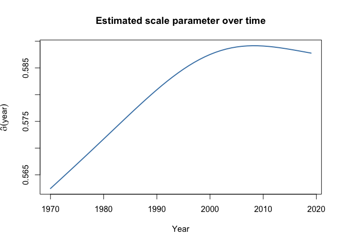

```r
year_grid <- data.frame(year = 1970:2019)
pred_yr <- predict(fit1_yr, newdata = year_grid, type = "response")

plot(year_grid$year, pred_yr$scale, type = "l", lwd = 2, col = "steelblue",
     xlab = "Year", ylab = expression(hat(sigma)(year)),
     main = "Estimated scale parameter over time")
```

## Quantile predictions

The `predict` method with `type = "quantile"` computes quantiles from the fitted model.

```r
probs <- c(0.5, 0.9, 0.95, 0.99)
qpred <- predict(fit1, type = "quantile", prob = probs)
emp_q <- quantile(df$y, probs)

data.frame(
  probability = probs,
  empirical   = round(as.numeric(emp_q), 3),
  fitted      = round(as.numeric(unlist(qpred[1, ])), 3),
  row.names   = NULL
)
```

```
#>   probability empirical fitted
#> 1        0.50       1.1  1.188
#> 2        0.90       2.8  2.772
#> 3        0.95       3.3  3.531
#> 4        0.99       4.4  5.617
```

These are quantiles of the exceedance distribution. To obtain return levels on the original temperature scale, add the threshold (33.9 °C) back.